# Customer Churn Prediction Project

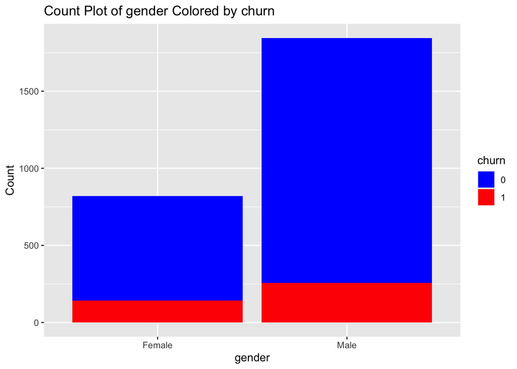

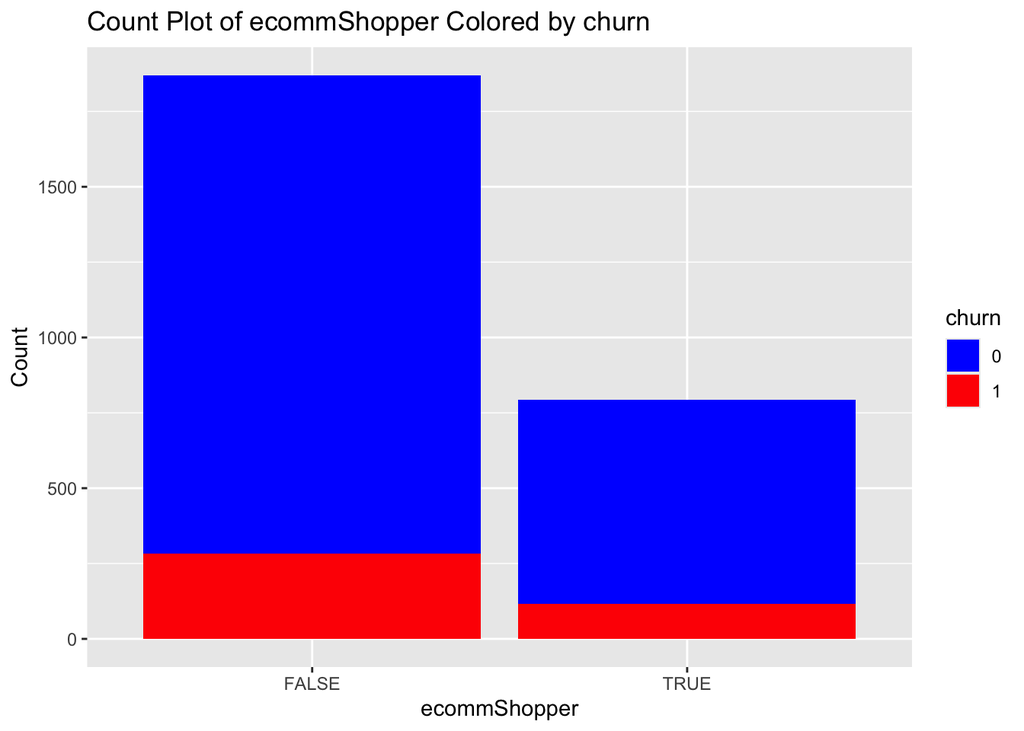

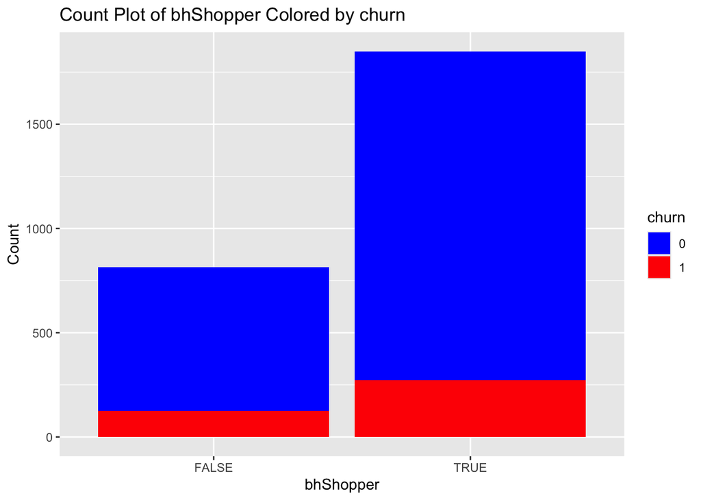

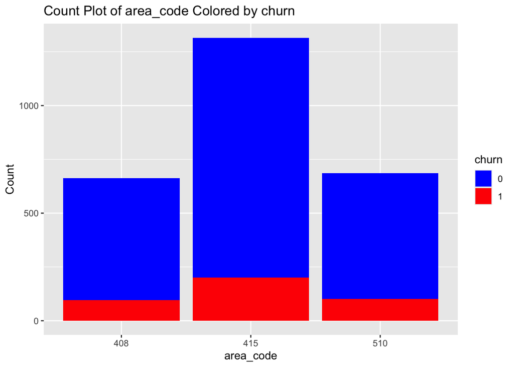

```r
for (cat_var in categorical_cols) {
  p <- ggplot(customer_data, aes(x = factor(!!as.name(cat_var)), fill = factor(customer_data$churn))) +
    geom_bar() +
    labs(
      title = paste("Count Plot of", cat_var, "Colored by churn"),
      x = cat_var,
      y = "Count"
    ) +
    scale_fill_manual(values = c("0" = "blue", "1" = "red"), name = "churn")
  print(p)
}
```

Findings:

Variables “custserv_calls”, “acc_purchasers”, “shoe_orders”, and “apparel_orders” have more influence on the number of non-churns because the percentage changes in non-churns are much more significant than the percentage changes in churns for different X values.

Variables ’promo_purchaser”, “acc_orders”, “gender”, “ecommShopper”, “bhShopper”, and “area_code” have roughly similar influence on churns and no-churns because the percentage changes in non-churns are similar to the percentage changes in churns for different X values.

In conclusion, all variables above could impact our dependent “churn” variable to certain degree.

## Preprocessing/Feature Engineering

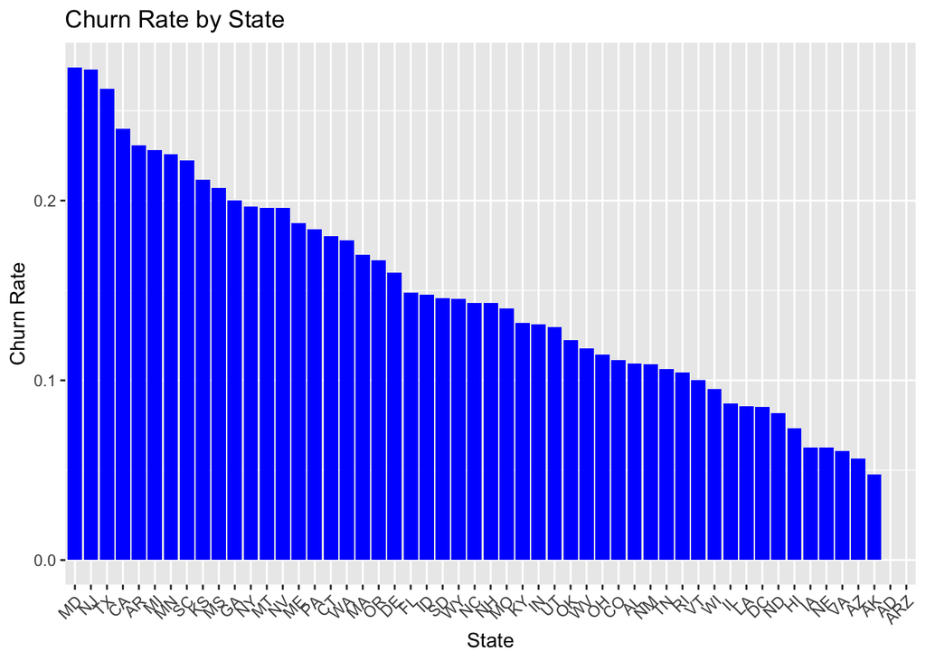

```r
# One-hot-encoding for 'state' variable and look at each state's churn rate.
# Prepare for feature engineering

customer_data <- customer_data %>%
  mutate_at(vars(state, churn), as.factor)

churn_rates <- customer_data %>%
  group_by(state) %>%
  summarise(
    total_records = n(),
    churn_count = sum(churn == "1"),
    churn_rate = churn_count / total_records
  ) %>%
  arrange(desc(churn_rate))

ggplot(churn_rates, aes(x = reorder(state, -churn_rate), y = churn_rate)) +
  geom_bar(stat = "identity", fill = "blue") +
  labs(
    title = "Churn Rate by State",
    x = "State",
    y = "Churn Rate"
  ) +
  theme(axis.text.x = element_text(angle = 45, hjust = 1))
```

```r
# Filter out states with churn rate higher than 0.2
filtered_states <- churn_rates %>%
  filter(churn_rate > 0.2)
filtered_states
```

```
## # A tibble: 10 × 4
##    state total_records churn_count churn_rate
##    <fct>         <int>       <int>      <dbl>
##  1 MD               62          17      0.274
##  2 NJ               55          15      0.273
##  3 TX               61          16      0.262
##  4 CA               25           6      0.24
##  5 AR               39           9      0.231
##  6 MI               57          13      0.228
##  7 MN               62          14      0.226
##  8 SC               45          10      0.222
##  9 KS               52          11      0.212
## 10 MS               58          12      0.207
```

I used churn rate of 0.2 as the threshold to determine the importance of each state and there are 10 states that have churn rates higher than 0.2. I will include these states into my model later.

```r
# Create one-hot-encoding for states with churn rates higher than 0.2 and delete original
# state variable.
selected_states <- c("stateMD", "stateNJ", "stateCA", "stateTX", "stateAR", "stateMI",
                     "stateMN", "stateSC", "stateKS", "stateMS")

encoded_state <- model.matrix(~state - 1, data = customer_data)
customer_data <- cbind(customer_data, encoded_state)
customer_data$state <- NULL

customer_data <- cbind(customer_data[, c(1:17)], customer_data[, selected_states])
```

```r
# Do one-hot-encoding for categorical variable gender
encoded_gender <- model.matrix(~gender - 1, data = customer_data)
customer_data <- cbind(customer_data, encoded_gender)
customer_data$gender <- NULL
```

```r
# Turn logical variables "ecommShopper" and "bhShopper" into binary variables
customer_data$ecommShopper <- as.integer(customer_data$ecommShopper)
customer_data$bhShopper <- as.integer(customer_data$bhShopper)
```

```r
# Do one-hot-encoding for categorical variable area_code
encoded_area_code <- model.matrix(~area_code - 1, data = customer_data)
customer_data <- cbind(customer_data, encoded_area_code)
customer_data$area_code <- NULL
```

```r
# Delete one column from each of the 4 highly-correlated pairs mentioned earlier
# Delete the phone column since it's not helpful for predicting customer churns.
# Deleted "genderMale" and "area_code510" because "genderMale" is highly correlated to "genderFemale" and "area_code510" is highly correlated to the other two areas.
remove_cols <-c("shoe_orders", "acc_orders", "apparel_orders", "promo_purchaser", "phone", "genderMale", "area_code510")
customer_data <- customer_data[, !(names(customer_data) %in% remove_cols)]
```

## Model Selection

### 1. Logistic Regression

First model I tried is logistic regression because it’s good at predicting binary outcomes and has high interpretability. Also, it handles both categorical and numerical variables very well and is efficient with small data sets.

```r
# Create validation set
validation_prop <- 0.2
num_validation <- round(nrow(customer_data) * validation_prop)
validation_index <- sample(1:nrow(customer_data), num_validation)
validation_set <- customer_data[validation_index, ]
training_set <- customer_data[-validation_index, ]
```

```r
# Perform logistic regression on the training set
set.seed(123)
logistic_model <- glm(churn ~ ., data = training_set, family = binomial(link = "logit"))
summary(logistic_model)
```

```
##
## Call:
## glm(formula = churn ~ ., family = binomial(link = "logit"), data = training_set)
##
## Coefficients:
##                  Estimate Std. Error z value Pr(>|z|)
## (Intercept)    -9.2037538  0.6776508 -13.582  < 2e-16 ***
## last_purchase  -0.0004811  0.0035311  -0.136  0.89162
## max_discount   -3.4773880  0.6310829  -5.510 3.58e-08 ***
## shoe_spend      0.0138318  0.0013638  10.142  < 2e-16 ***
## apparell_spend  0.0075931  0.0014265   5.323 1.02e-07 ***
## acc_spend       0.0109859  0.0025864   4.248 2.16e-05 ***
## custserv_calls  0.5084600  0.0493338  10.307  < 2e-16 ***
## acc_purchasers  2.0164329  0.1822515  11.064  < 2e-16 ***
## ecommShopper   -0.1184307  0.1527283  -0.775  0.43808
## bhShopper       0.0082721  0.1500006   0.055  0.95602
## stateMD         0.7226901  0.3847815   1.878  0.06036 .
## stateNJ         0.7592294  0.3807383   1.994  0.04614 *
## stateCA         1.6700855  0.5763590   2.898  0.00376 **
## stateTX         0.9030072  0.3742030   2.413  0.01582 *
## stateAR         0.4557297  0.5224915   0.872  0.38309
## stateMI         0.6545126  0.3935124   1.663  0.09626 .
## stateMN         0.6219323  0.3979713   1.563  0.11811
## stateSC         0.9090756  0.4755293   1.912  0.05591 .
## stateKS         0.4643125  0.4932551   0.941  0.34654
## stateMS         0.7175902  0.4114503   1.744  0.08115 .
## genderFemale    0.4405997  0.1450538   3.037  0.00239 **
## area_code408    0.1858067  0.1998166   0.930  0.35243
## area_code415    0.2019198  0.1706344   1.183  0.23667
## ---
## Signif. codes:  0 '***' 0.001 '**' 0.01 '*' 0.05 '.' 0.1 ' ' 1
##
## (Dispersion parameter for binomial family taken to be 1)
##
##     Null deviance: 1809.7  on 2130  degrees of freedom
## Residual deviance: 1391.7  on 2108  degrees of freedom
## AIC: 1437.7
##
## Number of Fisher Scoring iterations: 6
```

Findings:

According to the logistic regression model results, the coefficients of variables “max_discount”, “shoe_spend”, “apparell_spend”, “acc_spend”, “custserv_calls”, “acc_purchasers” are statistically significant and different from 0 under 0.1% significance level. The coefficients of “stateCA” and “genderFemale” are statistically significant and different from 0 under 1% significance level. The coefficients of “stateNJ” and “stateTX” are statistically significant and different from 0 under 5% significance level.

```r
# Use the logistic model on the validation set
logit_pred <- predict(logistic_model, newdata = validation_set, type = "response")

# Convert predicted probabilities to binary class labels
logit_predicted_churn <- ifelse(logit_pred >= 0.5, "1", "0")

# Calculate f1 score for validation set
logit_f1 <- F1_Score(validation_set$churn, logit_predicted_churn)
logit_f1
```

```
## [1] 0.9280501
```

The F1 score of the logistic model on the validation set is 0.928. I kept the threshold probability of predicting customer churn as 0.5 because it’s good to be conservative and target at all potential customers who are likely to churn with customized campaigns to avoid churn actions.

### 2. Random Forest

Second model I tried is random forest because it has high predictive accuracy in binary classification, which fits our purpose. Due to its ensemble nature, it effectively avoids over-fitting problems. Also, it can handle imbalanced data and some of our columns have imbalanced classes.

```r
# Train the random forest model in the train set
set.seed(123)
rf <- randomForest(churn ~ ., data = training_set, ntree = 100, proximity = TRUE)
print(rf)
```

```
##
## Call:
##  randomForest(formula = churn ~ ., data = training_set, ntree = 100,      proximity = TRUE)
##                Type of random forest: classification
##                      Number of trees: 100
## No. of variables tried at each split: 4
##
##         OOB estimate of  error rate: 7.51%
## Confusion matrix:
##      0   1 class.error
## 0 1786  23  0.01271421
## 1  137 185  0.42546584
```

```r
# Use random forest model on validation set
rf_pred <- predict(rf, newdata = validation_set, type = "response")
rf_f1 <- F1_Score(validation_set$churn, rf_pred)
rf_f1
```

```
## [1] 0.9628055
```

The F1 score of random forest model on the validation set is 0.963.

### Choose Random Forest Over Logistic Regression

The model metric I used to assess the model performance is F1 score because it balances precision and recall and can deal with imbalanced data sets to prevent models from being overly biased toward the majority class. So it works for our data set where there are several imbalanced columns. It also takes into consideration of both false positives and false negatives, making it a robust metric for our case. We want to lower false positives to limit the number of target customers to reduce campaign costs. We also want to lower false negatives to accurately target unloyal customers to increase customer retention.

The F1 score from validation set for logistic regression is 0.928 and the one for random forest is 0.963 so I chose random forest model to proceed.

### Find Optimal Random Forest Model via Hyperparameter Tuning

```r
# Tune hyper-parameters using validation set
param_grid <- expand.grid(
  ntree = c(50, 100, 150, 200),
  mtry = c(2, 4, 6, 8)
)

best_ntree <- NULL
best_mtry <- NULL
best_f1 <- 0
best_model <- NULL

set.seed(128)

for (i in 1:nrow(param_grid)) {
  model <- randomForest(
    churn ~ ., data = training_set, ntree = param_grid$ntree[i], mtry = param_grid$mtry[i]
  )

  predictions <- predict(model, newdata = validation_set)
  f1 <- F1_Score(validation_set$churn, predictions)

  if (f1 > best_f1) {
    best_f1 <- f1
    best_model <- model
    best_ntree <- param_grid$ntree[i]
    best_mtry <- param_grid$mtry[i]
  }
}
print(f1)
```

```
## [1] 0.9636752
```

```r
print(best_ntree)
```

```
## [1] 150
```

```r
print(best_mtry)
```

```
## [1] 8
```

The random forest model after hyper-parameter tuning has a F1 score of 0.964 on the validation set. Since it’s a slight improvement from the previous F1 score 0.963, I chose this model as the optimal model(ntree = 150, mtry = 8).

### Build Optimal Model with Best Hyperparameters

```r
set.seed(128)
optimal_rf <- randomForest(churn ~ ., data = training_set, ntree = 150, mtry = 8, proximity = TRUE)
print(optimal_rf)
```

```
##
## Call:
##  randomForest(formula = churn ~ ., data = training_set, ntree = 150,      mtry = 8, proximity = TRUE)
##                Type of random forest: classification
##                      Number of trees: 150
## No. of variables tried at each split: 8
##
##         OOB estimate of  error rate: 6.9%
## Confusion matrix:
##      0   1 class.error
## 0 1779  30  0.01658375
## 1  117 205  0.36335404
```

### Comprehensive Evaluation of the Optimal Model on Validation Set

```r
best_pred <- predict(optimal_rf, newdata = validation_set)
confusion_matrix <- confusionMatrix(best_pred, validation_set$churn)
print(confusion_matrix)
```

```
## Confusion Matrix and Statistics
##
##           Reference
## Prediction   0   1
##          0 451  28
##          1   7  47
##
##                Accuracy : 0.9343
##                  95% CI : (0.9099, 0.9538)
##     No Information Rate : 0.8593
##     P-Value [Acc > NIR] : 3.582e-08
##
##                   Kappa : 0.6925
##
##  Mcnemar's Test P-Value : 0.0007232
##
##             Sensitivity : 0.9847
##             Specificity : 0.6267
##          Pos Pred Value : 0.9415
##          Neg Pred Value : 0.8704
##              Prevalence : 0.8593
##          Detection Rate : 0.8462
##    Detection Prevalence : 0.8987
##       Balanced Accuracy : 0.8057
##
##        'Positive' Class : 0
##
```

Performance Evaluation:

This optimal model is 98% correct at predicting non-churn customers and 63% correct at predicting churned customers. Overall, it’s a good model to use. But such imbalanced model performance might be caused by the imbalanced classes in the Y label in the data set. Possible solutions include obtaining more data points from minority class, or using machine learning techniques to randomly remove majority class data points or generate synthetic minority class data points.

Test Set:

Since our training set is relatively small, I chose not to split another test set for testing in order to keep as much information as possible in the training set. If an independent test performance result is needed, we could obtain Y labels from the test file that is given.

## Prediction on Test File

```r
customer_data_test <- read_csv("/Users/lize/Desktop/DBC/Under Armour/test.csv")
customer_data_test <- distinct(customer_data_test)
customer_data_test <- na.omit(customer_data_test)

customer_data_test$area_code <- as.character(customer_data_test$area_code)
customer_data_test$area_code <- as.factor(customer_data_test$area_code)

#selected_states <- c("stateMD", "stateNJ", "stateCA", "stateTX", "stateAR", "stateMI",
#                     "stateMN", "stateSC", "stateKS", "stateMS")

encoded_state_test <- model.matrix(~state - 1, data = customer_data_test)
customer_data_test <- cbind(customer_data_test, encoded_state_test)
customer_data_test$state <- NULL
customer_data_test <- cbind(customer_data_test[, c(1:16)], customer_data_test[, selected_states])


encoded_gender_test <- model.matrix(~gender - 1, data = customer_data_test)
customer_data_test <- cbind(customer_data_test, encoded_gender_test)
customer_data_test$gender <- NULL

customer_data_test$ecommShopper <- as.integer(customer_data_test$ecommShopper)
customer_data_test$bhShopper <- as.integer(customer_data_test$bhShopper)

encoded_area_code_test <- model.matrix(~area_code - 1, data = customer_data_test)
customer_data_test <- cbind(customer_data_test, encoded_area_code_test)
customer_data_test$area_code <- NULL

#remove_cols <-c("shoe_orders", "acc_orders", "apparel_orders", "promo_purchaser", "phone", #"genderMale", "area_code510")
customer_data_test <- customer_data_test[, !(names(customer_data_test) %in% remove_cols)]
```

```r
test_pred <- predict(optimal_rf, newdata = customer_data_test)
```

```r
result_df <- data.frame(Predictions = test_pred)
write.csv(result_df, file = "/Users/lize/Desktop/DBC/Under Armour/predicted_results.csv", row.names = FALSE)
```